# ggplot2 avancé - problèmes et solutions

# Pour la publication

## Combiner plusieurs graphiques

Une des questions de ggplot2 que je dois me faire poser le plus souvent est : comment combiner plusieurs graphiques dans une même image. La difficulté de cette question tient, entre autres, au fait que ce n’est pas une fonction directe de ggplot2. Elle provient de librairies externes, donc il existe de multiples façons de faire. Et ce n’est pas toutes les façons qui permettent d’utiliser correctement ggsave à la fin de tout pour produire un fichier haute-résolution.

La méthode que je vous propose ici est celle que j’ai trouvé la plus robuste au fil du temps. Vous aurez besoin pour y arriver de la librairie gridExtra

On prépare d’abord nos graphiques individuellement :

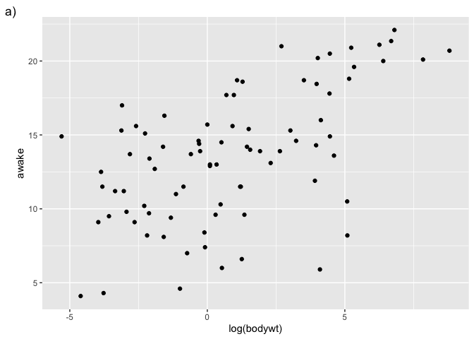

```r
g1 <- ggplot(msleep, aes(x = log(bodywt), y = awake)) + geom_point() +labs(tag = "a)")
g1
```

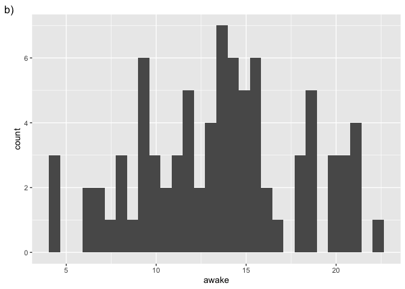

```r
g2 <- ggplot(msleep, aes(x = awake)) + geom_histogram() +labs(tag = "b)")
g2
```

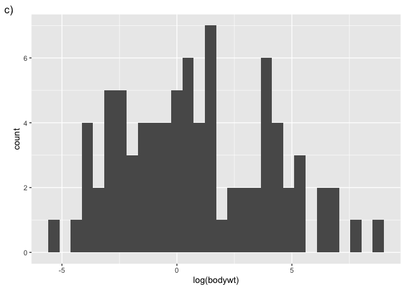

```r
g3 <- ggplot(msleep, aes(x = log(bodywt))) + geom_histogram() +labs(tag = "c)")
g3
```

Puis, la fonction arrangeGrob nous permet de les combiner :

```r
library(gridExtra)
p <- arrangeGrob(g1,g2,g3, nrow = 1)
```

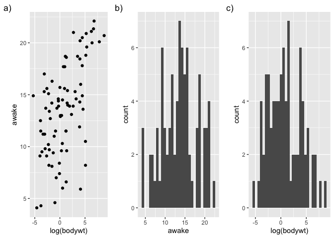

```r
grid::grid.draw(p) # Pour voir le graphique
```

```r
ggsave("test.jpg", p, width = 9, height = 4, dpi = 300) # Pour sauvegarder le graphique
```

On peut se préparer des *layouts* plus complexes avec définissant une matrice à utiliser :

```r
matrice <- rbind(c(1,1),
              c(2,3))

p <- arrangeGrob(g1,g2,g3, layout_matrix = matrice)
```

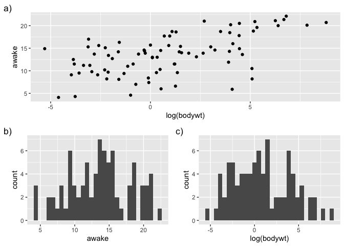

```r
grid::grid.draw(p)
```

```r
ggsave("test2.jpg", p, width = 4, height = 4, dpi = 300)
```

## Changer l’ordre de variables qualitatives

Une chose qui vous arrivera de temps à autre au moment de finaliser vos graphiques avant publication sera de vouloir modifier l’ordre des éléments associés à une variables qualitative, par exemple dans l’axe des X d’un boxplot.

Prenons ce petit graphique comme exemple :

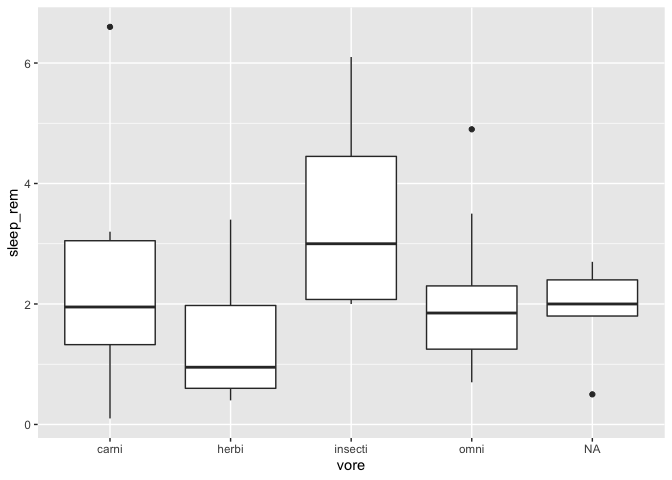

```r
ggplot(msleep, aes(x = vore, y = sleep_rem)) +
  geom_boxplot()
```

Une des choses que l’on pourrait vouloir changer dans ce graphique est de trier les types d’alimentation du plus petit au plus grand. En particulier si ce graphique est associé à un test statistique de type ANOVA.

La façon la plus simple de faire est de modifier l’ordre de notre variable catégorique dans le tableau de données avant de l’envoyer au grahpique. Il existe dans le `tidyverse` une librarie faite exprès pour manipuler les variables catégoriques, qui se nomme forcats.

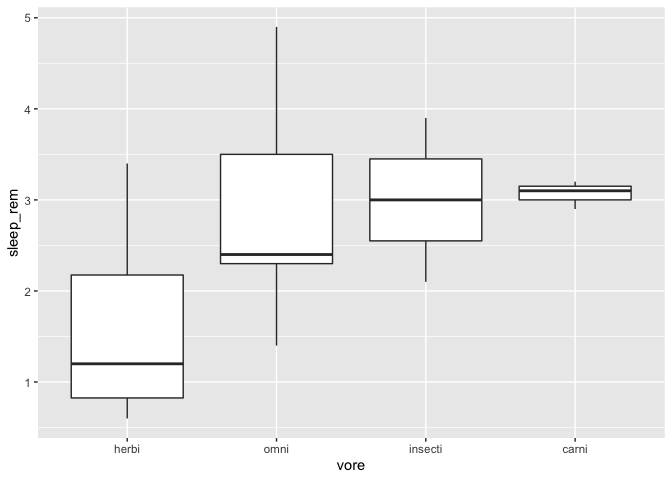

```r
library(forcats)
library(tidyr)

msleep %>%
  drop_na() %>%
  mutate(vore = fct_reorder(vore,sleep_rem)) %>%
  ggplot(aes(x = vore, y = sleep_rem)) +
  geom_boxplot()
```

Si on me mentionne rien, le tri se fait par la médiane des valeurs. On peut aussi spécifier une autre fonction, par exemple trier par la moyenne :

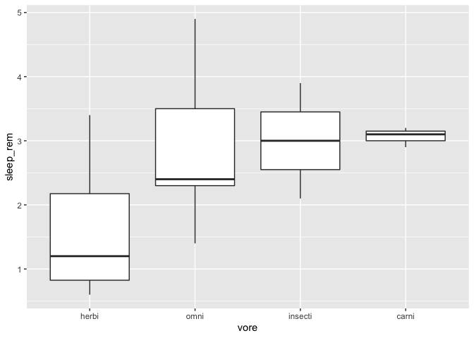

```r
msleep %>%
  drop_na() %>%
  mutate(vore = fct_reorder(vore,sleep_rem,mean)) %>%
  ggplot(aes(x = vore, y = sleep_rem)) +
  geom_boxplot()
```

On peut aussi choisir manuellement l’ordre des bandes manuellement, avec la fonction fct_relevel.

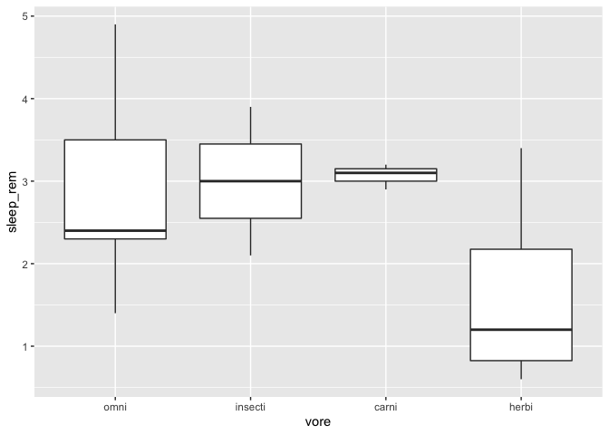

```r
msleep %>%
  drop_na() %>%
  mutate(vore = fct_relevel(vore,"omni","insecti")) %>%
  ggplot(aes(x = vore, y = sleep_rem)) +
  geom_boxplot()
```

Les niveaux non-mentionnés sont ajoutés à la fin de la liste, dans le même ordre qu’originalement.

## Ajouter de petites icônes ou images

Il est aussi possible d’ajouter de petits icônes (ou des grosses images!) à vos graphiques, en téléchargeant la librairie ggimage. Cette dernière ajoute un geom, nommé geom_image qui permet d’insérer des images.

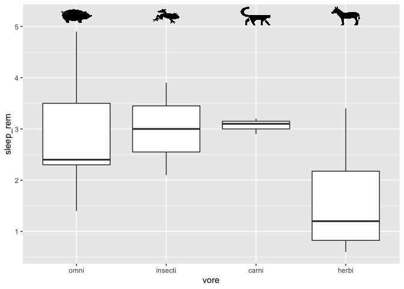

```r
library(ggimage)
msleep %>%
  drop_na() %>%
  mutate(vore = fct_relevel(vore,"omni","insecti")) %>%
  ggplot(aes(x = vore, y = sleep_rem)) +
  geom_boxplot() +
  geom_image(size = 0.08, aes(x = "herbi", y = 5.2, image = "https://static.thenounproject.com/png/2545-200.png")) +
  geom_image(size = 0.08,aes(x = "carni", y = 5.2, image = "https://static.thenounproject.com/png/18664-200.png")) +
  geom_image(size = 0.08,aes(x = "omni", y = 5.2, image = "https://static.thenounproject.com/png/5271-200.png")) +
  geom_image(size = 0.08,aes(x = "insecti", y = 5.2, image = "https://static.thenounproject.com/png/2546-200.png"))
```

Remarquez qu’il serait préférable de placer les images sur votre ordinateur et de fournir à R un chemin du genre `c:\Windows\etc.` car si l’image disparaît du site, votre graphique ne fonctionnera plus.

Remarquez aussi que, si vous avez plus de 2-3 images, il pourrait être préférable de stocker cette information dans un tableau de données plutôt que de tout faire à la main dans la graphique comme j’ai fait.

Enfin, ces images auraient été de bonnes candidates à la fonction annotate, mais au moment de terminer la formation, ça ne fonctionnait toujours pas. Peut-être que annotate ne fonctionne qu’avec les geom par défaut de ggplot2? À voir…

# Autres / Misc.

## Tracer n’importe quelle forme

Si vous avez besoin de dessiner quelque chose en particulier qui n’est pas déjà défini par un geom, sachez que vous pouvez préparer une série de coordonnées, et les faire connecter par un geom_path, par exemple comme ceci :

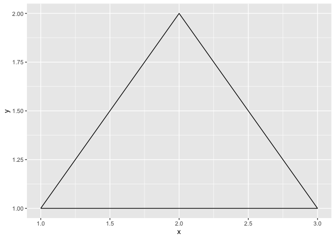

```r
data.frame(
  x = c(1,2,3,1),
  y = c(1,2,1,1)
) %>%
  ggplot(aes(x = x, y = y)) +
  geom_path()
```

Ça peut demander un peu de réflexion, mais vous pouvez vraiment faire CE QUE VOUS VOULEZ!

## Distributions marginales

Si jamais vous avez besoin d’ajouter des distributions marginales à un graphique avec ggplot2, sachez qu’il existe une fonction exprès pour cela dans la librairie ggExtra, qui se nomme ggMarginal. Elle s’utilise comme ceci :

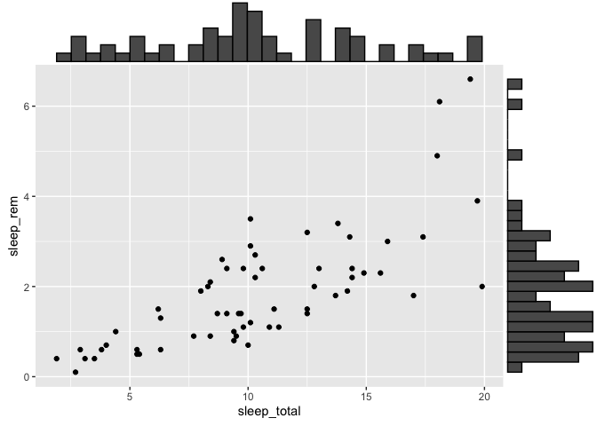

```r
library(ggExtra)
p <- ggplot(msleep, aes(x = sleep_total, y = sleep_rem)) +
  geom_point()
ggMarginal(p, type = "histogram")
```

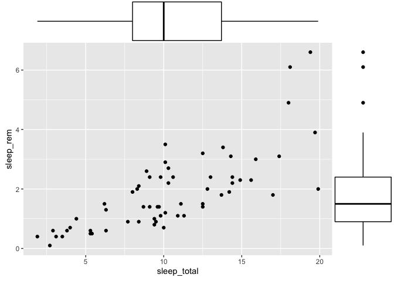

```r
ggMarginal(p, type = "boxplot")
```